# Food Data - Milk

Maria Leszczynska

2025-01-16

## Introduction:

In this analysis, we compare different types of milk to assess their nutritional content and determine which type may be the healthiest. The milk categories we focus on include **Whole Milk**, **Reduced Fat (2%)**, **Low Fat (1%)**, **Fat Free (Skim)**, **Human Milk**, **Evaporated/Condensed**, and **Malted/Special Milk**. We specifically examine the following nutrients: - **Protein**: Essential for muscle building and overall health. - **Fat**: Includes various types such as monounsaturated, polyunsaturated, and saturated fats. - **Calcium**: Important for bone health. - **Cholesterol**: Often a factor in determining heart health. - **Vitamin A**: Essential for vision and immune system function.

```
##  [1] "Category"                       "Description"
##  [3] "Nutrient.Data.Bank.Number"      "Data.Alpha.Carotene"
##  [5] "Data.Beta.Carotene"             "Data.Beta.Cryptoxanthin"
##  [7] "Data.Carbohydrate"              "Data.Cholesterol"
##  [9] "Data.Choline"                   "Data.Fiber"
## [11] "Data.Lutein.and.Zeaxanthin"     "Data.Lycopene"
## [13] "Data.Niacin"                    "Data.Protein"
## [15] "Data.Retinol"                   "Data.Riboflavin"
## [17] "Data.Selenium"                  "Data.Sugar.Total"
## [19] "Data.Thiamin"                   "Data.Water"
## [21] "Data.Fat.Monosaturated.Fat"     "Data.Fat.Polysaturated.Fat"
## [23] "Data.Fat.Saturated.Fat"         "Data.Fat.Total.Lipid"
## [25] "Data.Major.Minerals.Calcium"    "Data.Major.Minerals.Copper"
## [27] "Data.Major.Minerals.Iron"       "Data.Major.Minerals.Magnesium"
## [29] "Data.Major.Minerals.Phosphorus" "Data.Major.Minerals.Potassium"
## [31] "Data.Major.Minerals.Sodium"     "Data.Major.Minerals.Zinc"
## [33] "Data.Vitamins.Vitamin.A...RAE"  "Data.Vitamins.Vitamin.B12"
## [35] "Data.Vitamins.Vitamin.B6"       "Data.Vitamins.Vitamin.C"
## [37] "Data.Vitamins.Vitamin.E"        "Data.Vitamins.Vitamin.K"
```

```
##   Category                           Description Nutrient.Data.Bank.Number
## 1     Milk                           Milk, human                  11000000
## 2     Milk                             Milk, NFS                  11100000
## 3     Milk                           Milk, whole                  11111000
## 4     Milk               Milk, low sodium, whole                  11111100
## 5     Milk        Milk, calcium fortified, whole                  11111150
## 6     Milk Milk, calcium fortified, low fat (1%)                  11111160
##   Data.Alpha.Carotene Data.Beta.Carotene Data.Beta.Cryptoxanthin
## 1                   0                  7                       0
## 2                   0                  4                       0
## 3                   0                  7                       0
## 4                   0                  7                       0
## 5                   0                  7                       0
## 6                   0                  1                       0
##   Data.Carbohydrate Data.Cholesterol Data.Choline Data.Fiber
```

[output cut: 76 more lines]

```
##   Category Description Nutrient.Data.Bank.Number Data.Alpha.Carotene
## 1        0           0                         0                   0
##   Data.Beta.Carotene Data.Beta.Cryptoxanthin Data.Carbohydrate Data.Cholesterol
## 1                  0                       0                 0                0
##   Data.Choline Data.Fiber Data.Lutein.and.Zeaxanthin Data.Lycopene Data.Niacin
## 1            0          0                          0             0           0
##   Data.Protein Data.Retinol Data.Riboflavin Data.Selenium Data.Sugar.Total
## 1            0            0               0             0                0
##   Data.Thiamin Data.Water Data.Fat.Monosaturated.Fat Data.Fat.Polysaturated.Fat
## 1            0          0                          0                          0
##   Data.Fat.Saturated.Fat Data.Fat.Total.Lipid Data.Major.Minerals.Calcium
## 1                      0                    0                           0
##   Data.Major.Minerals.Copper Data.Major.Minerals.Iron
## 1                          0                        0
##   Data.Major.Minerals.Magnesium Data.Major.Minerals.Phosphorus
## 1                             0                              0
##   Data.Major.Minerals.Potassium Data.Major.Minerals.Sodium
## 1                             0                          0
##   Data.Major.Minerals.Zinc Data.Vitamins.Vitamin.A...RAE
## 1                        0                             0
##   Data.Vitamins.Vitamin.B12 Data.Vitamins.Vitamin.B6 Data.Vitamins.Vitamin.C
## 1                         0                        0                       0
##   Data.Vitamins.Vitamin.E Data.Vitamins.Vitamin.K
## 1                       0                       0
```

```
## [1] 0
```

[output not shown]

[output cut: 76 more lines]

### Average protein content across milk categories:

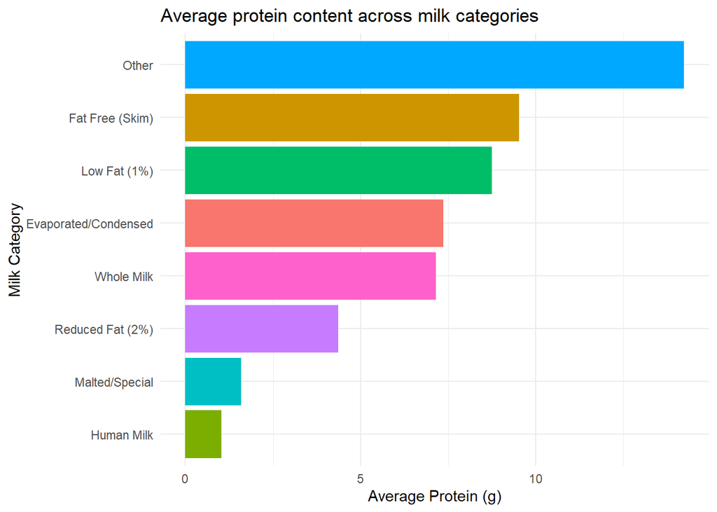

### What is the fat composition in different types of milk?

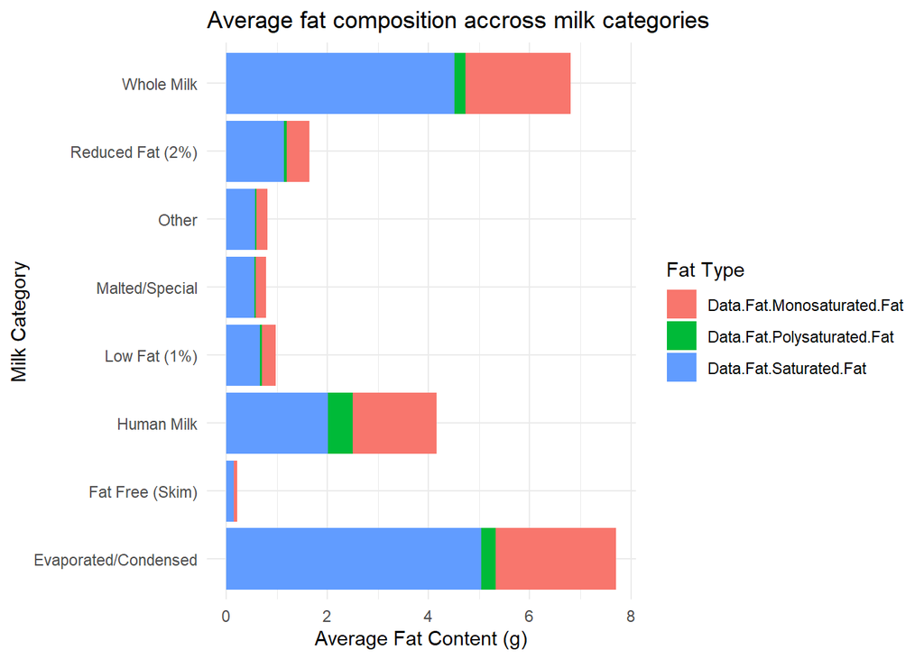

I will not consider condensed milk here, as it is just whole milk without water and I want to look at different liquid milk alternatives. The consumer needs to decide what is more important to them - one option is a large amount of “good” fats (aka the mono- and poly- saturated fats) - in which case the milk will also have a high content of saturated or “bad” fats, but will help them absorb other nutrient from foods better. They might also decide they want a low fat option to avoid saturated fats (in case of for example heart disease), in which case they will like skim milk better.

### Protein vs fat in milk:

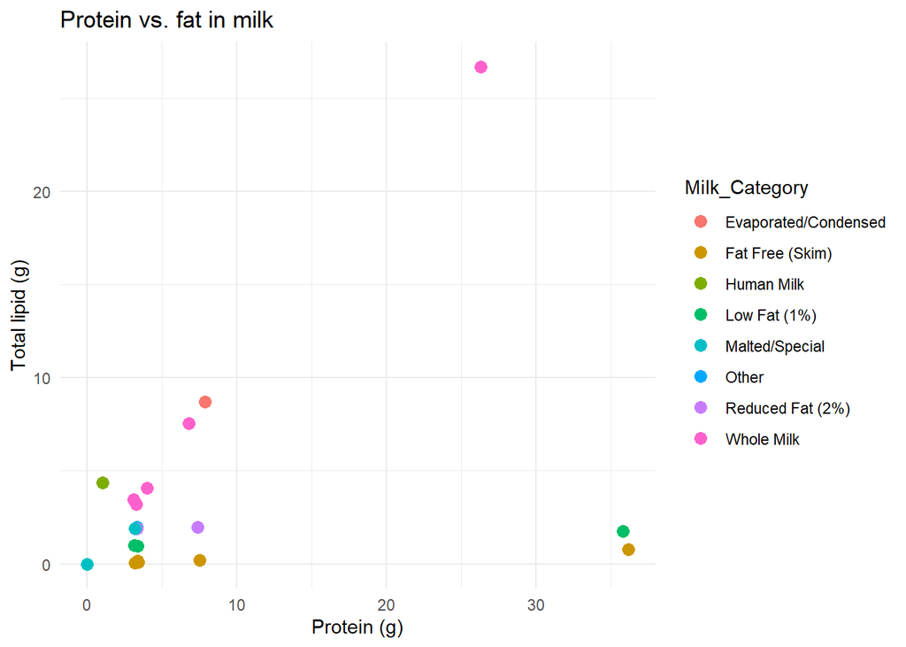

### Treemap of calcium content:

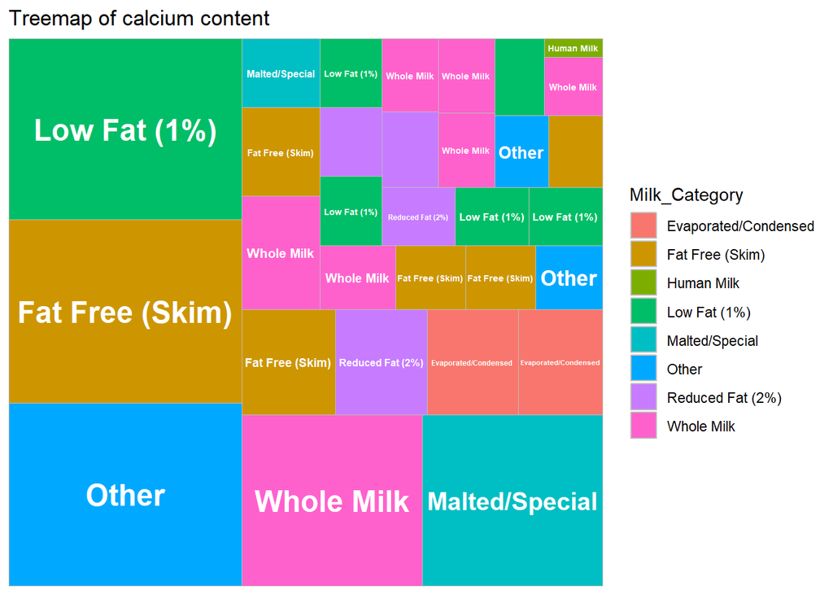

No category stands out as the best source of calcium, which is great since it’s a crucial nutrient for bone health.

### Treemap of vitamin A:

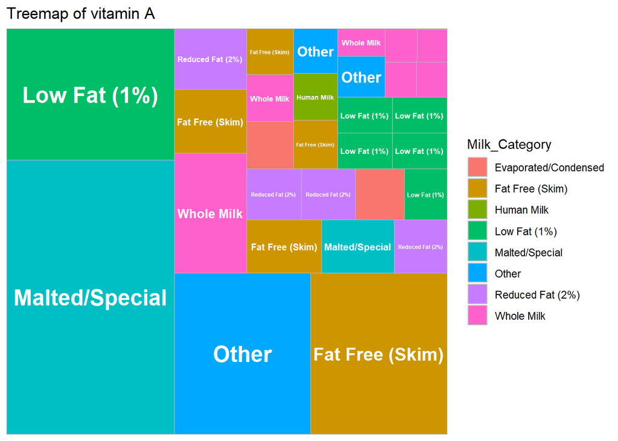

**Malted/Special** milk stands out as the one with the highest content of vitamin A, which is important for vision and our immune systems.

### Ridgeline plots for density distribution of nutrients:

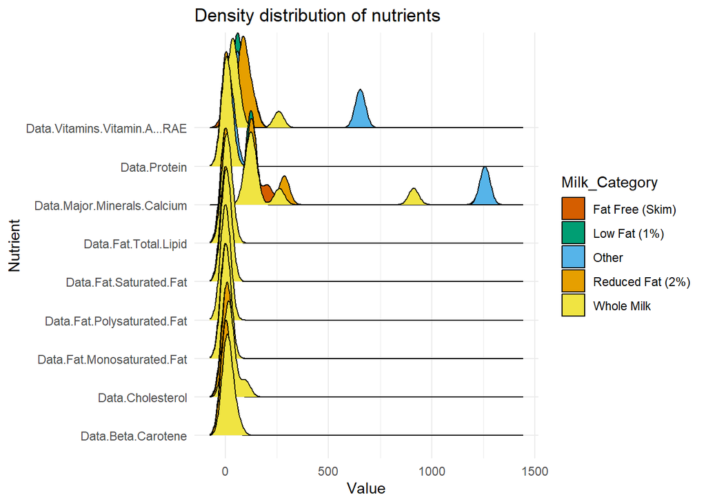

We cannot see that well because of outliers, so let us have a look at the data if we exclude them:

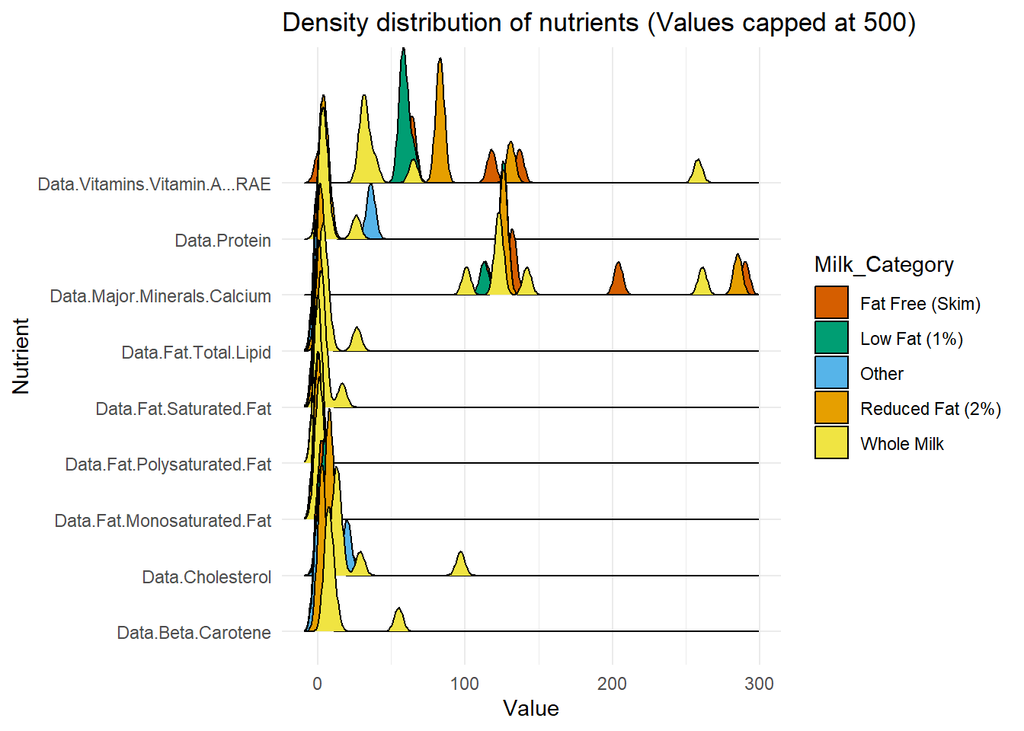

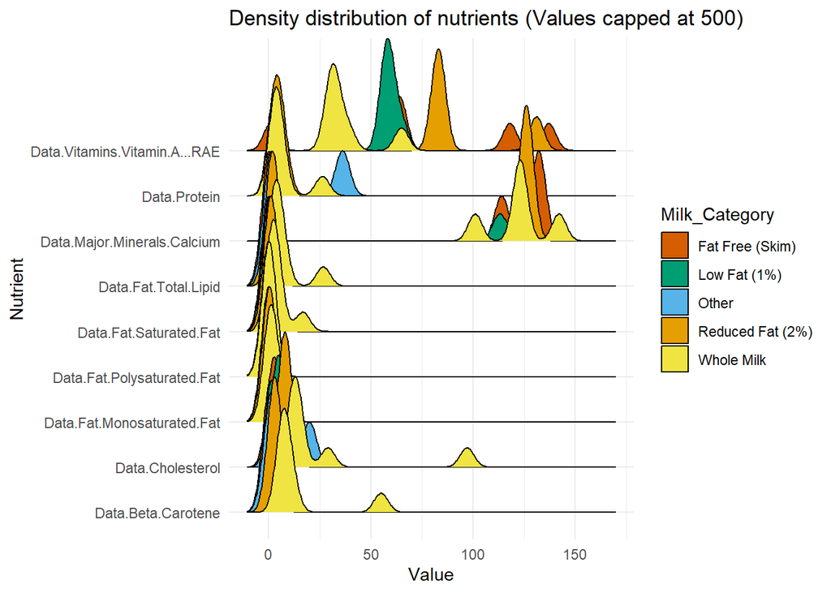

To me, whole milk stands out as the one with the best nutrient content, but the values are not spread that wide apart so it can be consumer’s choice.

### Violin plot:

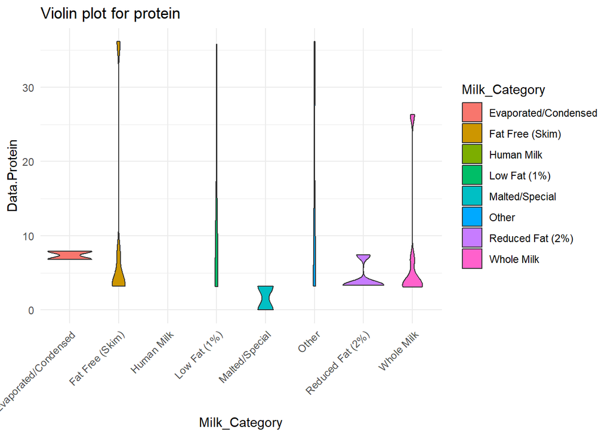

This violin plot did not work well since we do not have a large enough number of observations, but I wanted to try and see what it would look like :)

### Boxplots of protein and fat content:

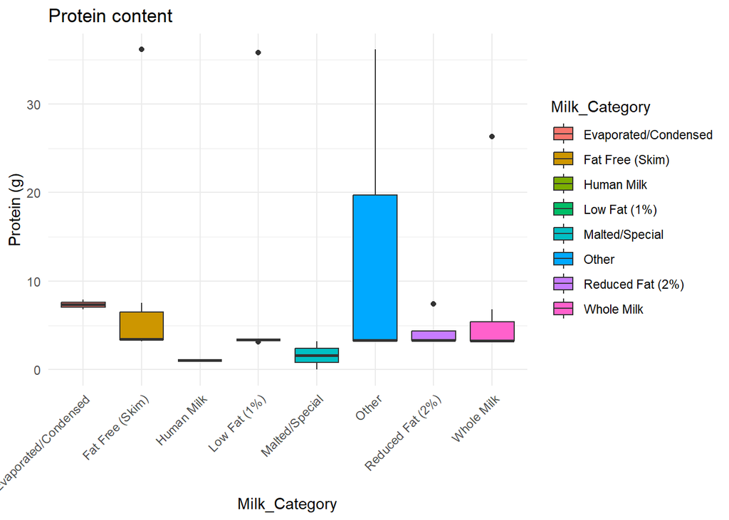

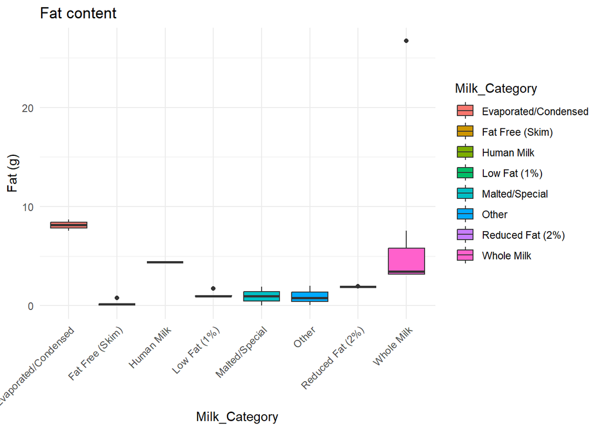

If we want a lot of protein, but as little fat as possible, skin milk might be our best choice.

### Protein vs calcium:

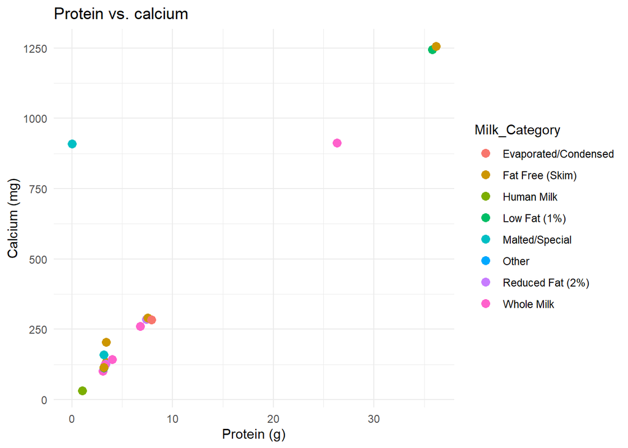

Besides a few outliers, we can see that calcium and protein content correlate slightly - the higher the protein content, the higher the calcium.

### Density plot for cholesterol and fat types:

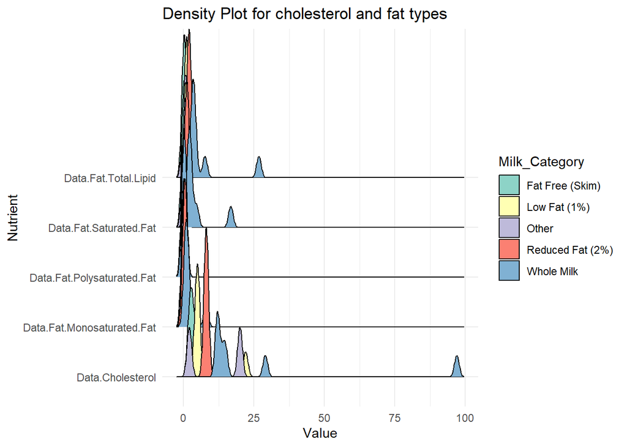

Let’s have a closer look without the outlier:

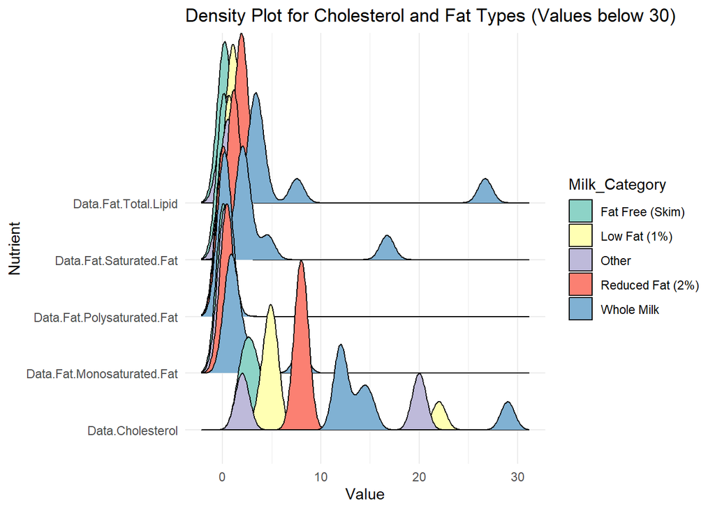

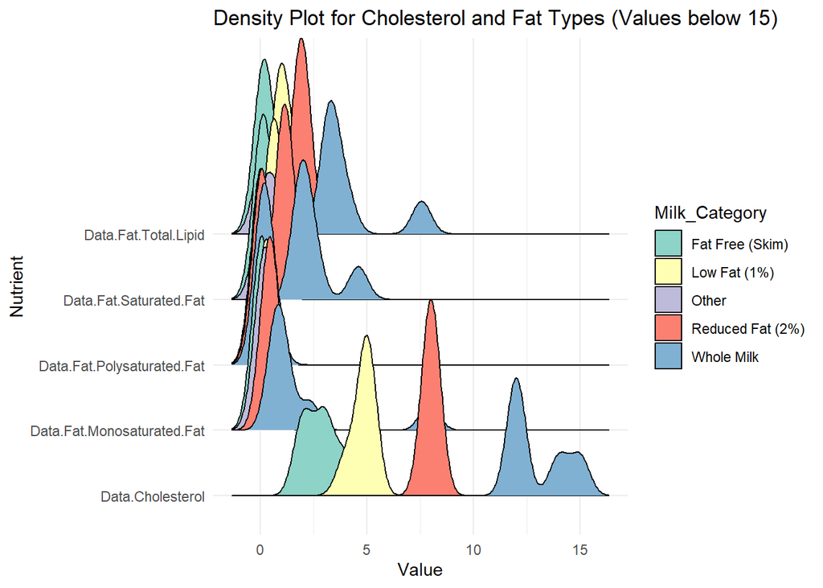

For someone who is trying to lower the amount of cholesterol in their diet, fat free milk is the best option, followed by low fat.

### Different plots for cholesterol and fat contents:

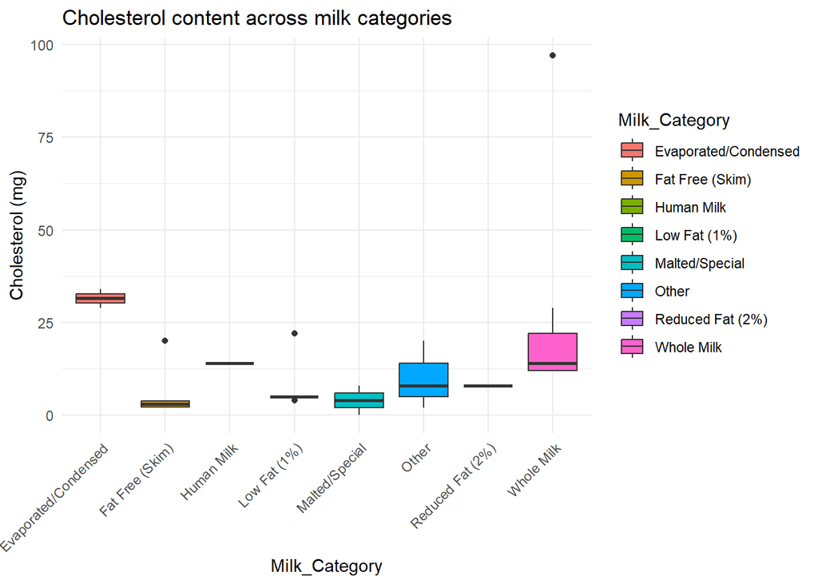

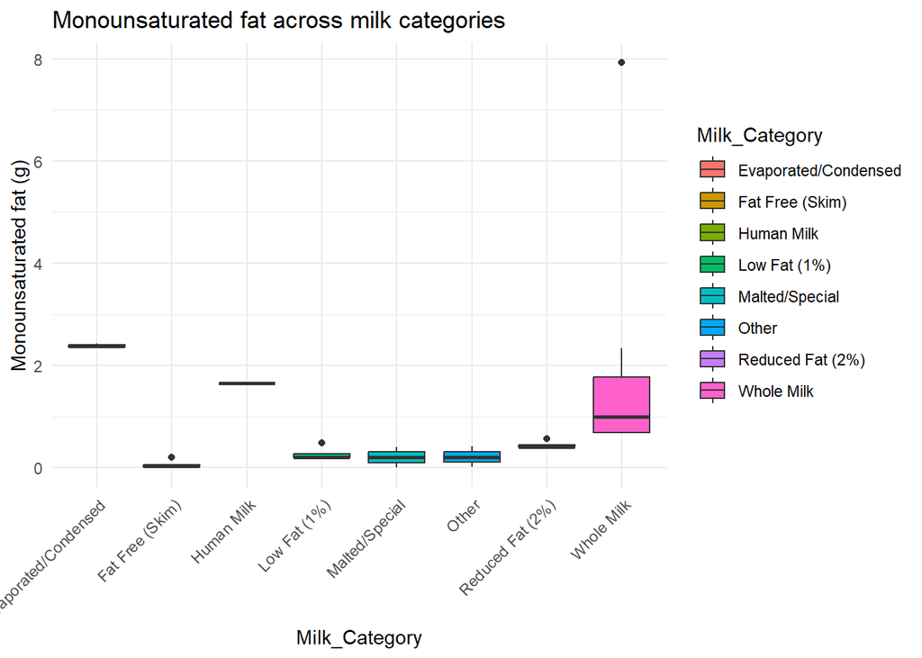

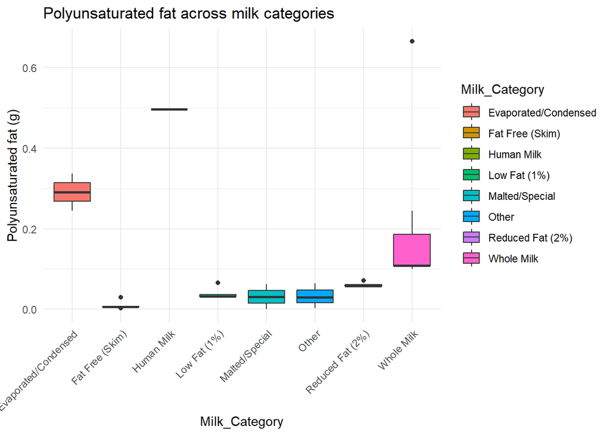

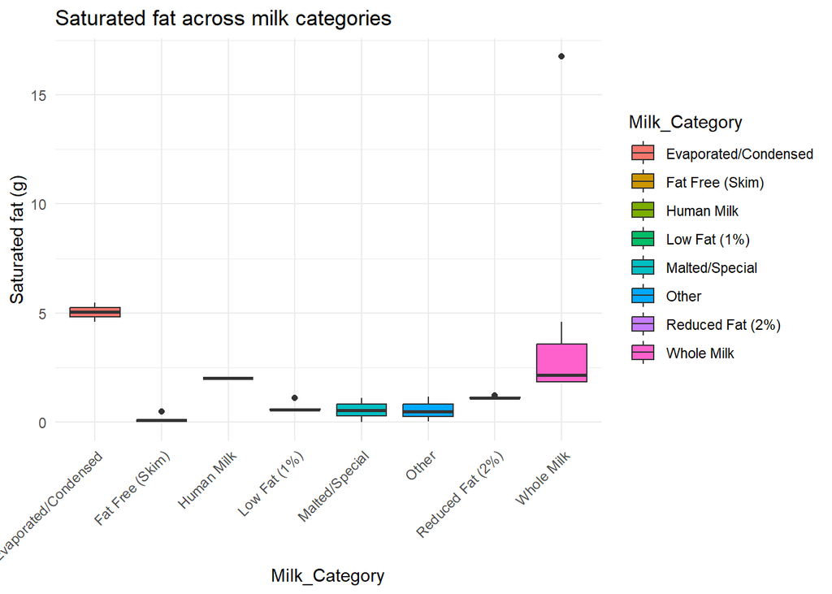

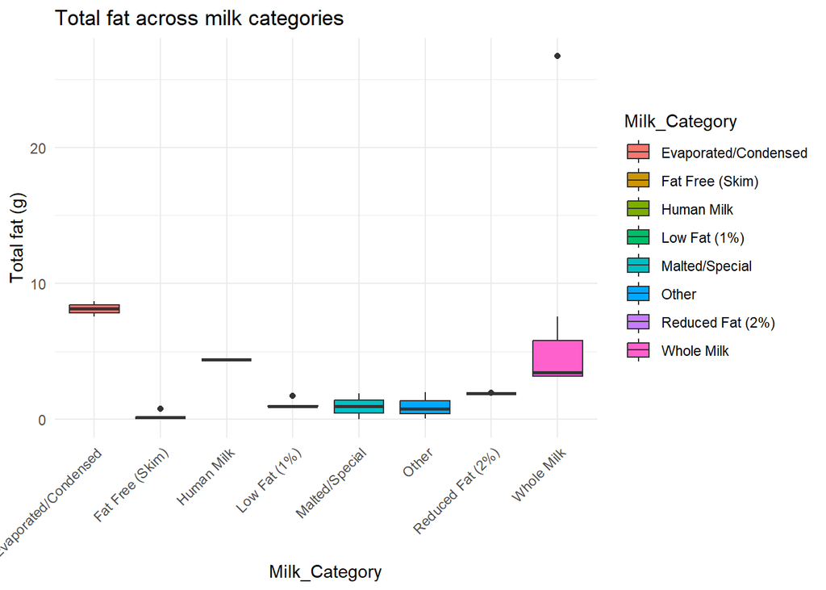

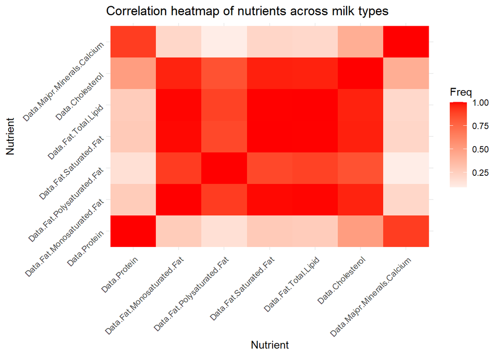